# Homework 2

Debi Gonzalez

2025-09-16

### Work through the next two lessons (Subsetting Vectors; Matrices and Data

Frames). Then answer the following questions. Show work (copy the R commands) for each question that requires output from R.

1. Create the following vector: 1,4,3,4,2,NA,5,NA,4,5,2,NA. Assign the vector to a variable of your choice. Please pull from x all values that are not “NA” and save those to a new variable called ‘nonas’. Then type print(nonas) and report the result.

```r
# 1. Create the vector and assign to a variable (call it x)
x <- c(1, 4, 3, 4, 2, NA, 5, NA, 4, 5, 2, NA)

# 2. Pull all values that are not NA and assign to 'nonas'
nonas <- x[!is.na(x)]

# 3. Print
print(nonas)
```

```
## [1] 1 4 3 4 2 5 4 5 2
```

2. Request from x only values that are both non-missing AND greater than zero. Print the result here.

```r
# Adding the x>0 condition

x[!is.na(x) & (x>0)]
```

```
## [1] 1 4 3 4 2 5 4 5 2
```

```r
# We can prob call this positive_nonas

positive_nonas <- x[!is.na(x) & (x>0)]
print(positive_nonas)
```

```
## [1] 1 4 3 4 2 5 4 5 2
```

```r
# testing my theory that nonas is technically already compliant with this request
print(nonas > 0)
```

```
## [1] TRUE TRUE TRUE TRUE TRUE TRUE TRUE TRUE TRUE
```

```r
nonas
```

```
## [1] 1 4 3 4 2 5 4 5 2
```

3. Subset the 9,12,15,22 elements of x.

```r
# Subsetting elements 9, 12, 15, 22... there are no elements 15 and 22 in our vector, so I expect NAs for those elements.

subset_x <- x[c(9, 12, 15, 22)]
print(subset_x)
```

```
## [1]  4 NA NA NA
```

4. Create an empty matrix with 5 rows and 4 columns.

```r
# Creating an empty matrix

empty_matrix <- matrix(nrow = 5, ncol = 4)

# Confirming output of empty matrix
print(empty_matrix)
```

```
##      [,1] [,2] [,3] [,4]
## [1,]   NA   NA   NA   NA
## [2,]   NA   NA   NA   NA
## [3,]   NA   NA   NA   NA
## [4,]   NA   NA   NA   NA
## [5,]   NA   NA   NA   NA
```

5. Create a matrix with data = c(1:40), with 4 rows and 10 columns.

```r
data_mat <- matrix(data = c(1:40), nrow = 4, ncol = 10)

print(data_mat)
```

```
##      [,1] [,2] [,3] [,4] [,5] [,6] [,7] [,8] [,9] [,10]
## [1,]    1    5    9   13   17   21   25   29   33    37
## [2,]    2    6   10   14   18   22   26   30   34    38
## [3,]    3    7   11   15   19   23   27   31   35    39
## [4,]    4    8   12   16   20   24   28   32   36    40
```

6. Create labels for the columns of your matrix. (Hint: Remember to tell R the labels are strings)

```r
# Creating the labels only

column_labels <- paste0("C", seq_len(ncol(data_mat)))

# I realized that this was not asking me to add it to the matrix just yet after I read the next question.
```

7. Using the colnames() function, add those column labels to your matrix.

```r
# Adding the column labels to the matrix

colnames(data_mat) <- column_labels
print(data_mat)
```

```
##      C1 C2 C3 C4 C5 C6 C7 C8 C9 C10
## [1,]  1  5  9 13 17 21 25 29 33  37
## [2,]  2  6 10 14 18 22 26 30 34  38
## [3,]  3  7 11 15 19 23 27 31 35  39
## [4,]  4  8 12 16 20 24 28 32 36  40
```

Other ways of adding column labels more directly:

```r
# Labeling the columns C1, C2, ..., C10, manually. Column names are in quotes to note that the labels are strings.
colnames(data_mat) <- c("C1","C2","C3","C4","C5",
                        "C6","C7","C8","C9","C10")

# Confirming all looks good
print(data_mat)
```

```
##      C1 C2 C3 C4 C5 C6 C7 C8 C9 C10
## [1,]  1  5  9 13 17 21 25 29 33  37
## [2,]  2  6 10 14 18 22 26 30 34  38
## [3,]  3  7 11 15 19 23 27 31 35  39
## [4,]  4  8 12 16 20 24 28 32 36  40
```

```r
# Another way of doing this with a bit less code

colnames(data_mat) <- paste0("C", seq_len(ncol(data_mat)))

print(data_mat)
```

```
##      C1 C2 C3 C4 C5 C6 C7 C8 C9 C10
## [1,]  1  5  9 13 17 21 25 29 33  37
## [2,]  2  6 10 14 18 22 26 30 34  38
## [3,]  3  7 11 15 19 23 27 31 35  39
## [4,]  4  8 12 16 20 24 28 32 36  40
```

8. This one is a little tricky, so please ask if you have questions. The purpose of it is to show you an annoying issue with R. Using either base R or ggplot2, please make a barplot from the ‘iris’ data. Use Species to predict Sepal Length. In a bit of a twist, please order the barplot from (left to right) highest sepal length to shortest sepal length.

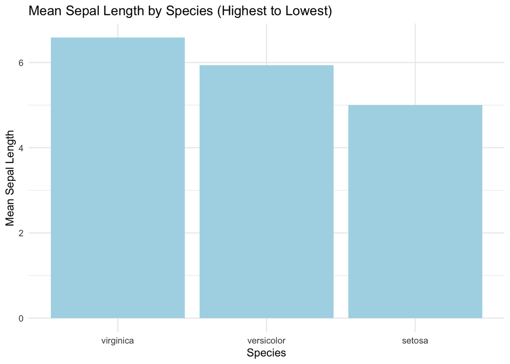

```r
# Call the data,
ggplot(iris,
       aes(x = reorder(Species, -Sepal.Length, FUN = mean), y = Sepal.Length)) +
  # setting x and y axis. Selecting Species as a factor for X, calculating the mean length for each species, and reordering it (this ensures it's going from highest to lowest mean).
  stat_summary(fun = mean, geom = "bar", fill = "lightblue") +
  # Computing summary statistic for each x-group (each species) --> the mean of Sepal.Length. Then we select the plot to be a bar plot reflecting the computed mean. Then, selecting color of the bars.
  labs(
    x = "Species",
    y = "Mean Sepal Length",
    title = "Mean Sepal Length by Species (Highest to Lowest)") +
  # labeling axis and title
  theme_minimal()
```

```r
# adding theme for aesthetic purposes
```